# Movie Recommendation: Recommender Systems

Omar Choudhry (oachoud2)

Muhammad Rafay (mrafay2)

Nitish Singla (nsingla2)

CS598, Fall 2020

```r
library(recommenderlab)
library(Matrix)
library(data.table)
library(Xmisc)
```

## Read in Data

```r
#Parsing ratings data
myurl = "https://liangfgithub.github.io/MovieData/"

ratings = read.csv('ratings.dat',
                   sep = ':',
                   colClasses = c('integer', 'NULL'),
                   header = FALSE)
colnames(ratings) = c('UserID', 'MovieID', 'Rating', 'Timestamp')
ratings$Timestamp = NULL

#Parsing movie ID Data
myurl = "https://liangfgithub.github.io/MovieData/"
movies = readLines(paste0(myurl, 'movies.dat?raw=true'))
movies = strsplit(movies, split = "::", fixed = TRUE, useBytes = TRUE)
movies = matrix(unlist(movies), ncol = 3, byrow = TRUE)
movies = data.frame(movies, stringsAsFactors = FALSE)
colnames(movies) = c('MovieID', 'Title', 'Genres')
movies$MovieID = as.integer(movies$MovieID)
movies$Title = iconv(movies$Title, "latin1", "UTF-8")
small_image_url = "https://liangfgithub.github.io/MovieImages/"
movies$image_url = sapply(movies$MovieID,
                          function(x) paste0(small_image_url, x, '.jpg?raw=true'))
```

## System I: Genre Based Recommendation

For system I we derived two recommendation models based on genre preferences of the user.

```r
genres = as.data.frame(movies$Genres, stringsAsFactors=FALSE)
tmp = as.data.frame(tstrsplit(genres[,1], '[|]', type.convert=TRUE), stringsAsFactors=FALSE)

genre_list = c("Action", "Adventure", "Animation",
               "Children's", "Comedy", "Crime",
               "Documentary", "Drama", "Fantasy",
               "Film-Noir", "Horror", "Musical",
               "Mystery", "Romance", "Sci-Fi",
               "Thriller", "War", "Western")

m = length(genre_list)
genre_matrix = matrix(0, nrow(movies), length(genre_list))
for(i in 1:nrow(tmp)){
  genre_matrix[i,genre_list %in% tmp[i,]]=1
}
colnames(genre_matrix) = genre_list
rownames(genre_matrix) = movies$MovieID

remove("tmp", "genres")

i = paste0('u', ratings$UserID)
j = paste0('m', ratings$MovieID)
x = ratings$Rating
tmp = data.frame(i, j, x, stringsAsFactors = T)
Rmat = sparseMatrix(as.integer(tmp$i), as.integer(tmp$j), x = tmp$x)
rownames(Rmat) = levels(tmp$i)
colnames(Rmat) = levels(tmp$j)
Rmat = new('realRatingMatrix', data = Rmat)
```

### Scheme 1: Recommend Highest Rated Movies

The first scheme is based on the highest average ratings of movies within each genre. To compute this we take a number of steps below.

```r
movieAvgRat  = colMeans(as(Rmat, 'matrix'), na.rm = TRUE)

genre_highly_rated_matrix = matrix(NA, 18, length(unique(ratings$MovieID)))
rownames(genre_highly_rated_matrix) = genre_list

Rmat_Cols  = strtoi(strip(colnames(Rmat), char="m"))

for(i in 1:18) {

  tmp = data.frame(id = movies$MovieID[genre_matrix[,i] == 1], rat = 1:length(movies$MovieID[genre_matrix[,i] == 1]))
  tmp[,2] =NA

  tmp2 = movieAvgRat[Rmat_Cols %in% movies$MovieID[genre_matrix[,i] == 1]]

  for(j in tmp$id){
    if(!is.na(j)){
      tmp[which(tmp$id == j),2] = tmp2[paste0('m',j)]
    }
  }

  tmp = tmp[order(tmp$rat,decreasing = TRUE),]
  for(k in 1:dim(tmp)[1]){
    if(!is.na(tmp[k,2])){
      genre_highly_rated_matrix[i,k] = tmp[k,1]
    }
  }
}
```

First we iterate to sort all movies into the 18 genres. After, we are getting a list of the movies for a specific genre, then sorting the movies within the genre based on movies that received the highest average rating from Movie Lens users. This is then stored in a matrix for our shiny app to access.

### Scheme 2: Recommend Most Popular Movies

Our second scheme follows the first scheme closely algorithm wise, with a couple of key differences as we are trying to rank the movies with each genre based on popularity rather than highest average rating.

```r
temp = as(Rmat, 'matrix')
temp[which(temp < 3)] = NA
temp[which(temp >= 3)] = 1

moviePopCount = colSums(temp, na.rm = TRUE)

genre_most_popular_matrix = matrix(NA, 18, length(unique(ratings$MovieID)))
rownames(genre_most_popular_matrix) = genre_list

for(i in 1:18) {

  tmp = data.frame(id = movies$MovieID[genre_matrix[,i] == 1], rat = 1:length(movies$MovieID[genre_matrix[,i] == 1]))
  tmp[,2] =NA

  tmp2 = moviePopCount[Rmat_Cols %in% movies$MovieID[genre_matrix[,i] == 1]]

  for(j in tmp$id){
    if(!is.na(j)){
      tmp[which(tmp$id == j),2] = tmp2[paste0('m',j)]
    }
  }

  tmp = tmp[order(tmp$rat,decreasing = TRUE),]
  for(k in 1:dim(tmp)[1]){
    if(!is.na(tmp[k,2])){
      genre_most_popular_matrix[i,k] = tmp[k,1]
    }
  }
}
```

## System II: Collaborative Recommnedation System

For system 2 we opted to leverage User based and Item based Collaborative filtering. All technical details of our implementation are discuessed below. This inlcudes evaluation metrics, evaulation process, and rationale for use of various tuning parameters.

### Training Test Split

**train** data that contain about 80% rows of `ratings.dat`

**test** data that contain about 20% of rows of `ratings.dat`

```r
set.seed(100)
train.id = sample(nrow(ratings), floor(nrow(ratings)) * 0.8)
train = ratings[train.id, ]
head(train)
```

|  | UserID | MovieID | Rating |
| --- | --- | --- | --- |
| 606711 | 3683 | 1962 | 1 |
| 331376 | 1958 | 3258 | 3 |
| 162777 | 1039 | 2856 | 1 |
| 614094 | 3720 | 2067 | 5 |
| 732055 | 4379 | 3614 | 2 |
| 353796 | 2072 | 2967 | 4 |

```r
test = ratings[-train.id, ]
head(test)
```

|  | UserID | MovieID | Rating |
| --- | --- | --- | --- |
| 5 | 1 | 2355 | 5 |
| 16 | 1 | 2791 | 4 |
| 17 | 1 | 2687 | 3 |
| 28 | 1 | 1721 | 4 |
| 32 | 1 | 3186 | 4 |
| 40 | 1 | 150 | 5 |

### Recommender System

First we create a utility matrix stored as a sparse matrix.

```r
i = paste0('u', train$UserID)
j = paste0('m', train$MovieID)
x = train$Rating
tmp = data.frame(i, j, x, stringsAsFactors = T)
Rmat = sparseMatrix(as.integer(tmp$i), as.integer(tmp$j), x = tmp$x)
rownames(Rmat) = levels(tmp$i)
colnames(Rmat) = levels(tmp$j)
Rmat = new('realRatingMatrix', data = Rmat)
```

`Rmat` is a 6040-by-3681 sparse matrix. Its rows correspond to the unique 6040 users in the training data, and columns correspond to the unique 3681 movies in the training data (although the MovieIDs range from 1 to 3952).

```r
range(train$MovieID)
length(unique(train$MovieID))
range(train$UserID)
length(unique(train$UserID))
dim(Rmat)
```

Train a recommender system using R package [[recommenderlab](https://cran.r-project.org/web/packages/recommenderlab/vignettes/recommenderlab.pdf)]

```r
rec_UBCF = Recommender(Rmat, method = 'UBCF',
                  parameter = list(normalize = 'Z-score',
                                   method = 'Cosine',
                                   nn = 25))
#Summary of model parameters
rec_UBCF@model
```

```
## $description
## [1] "UBCF-Real data: contains full or sample of data set"
##
## $data
## 6040 x 3681 rating matrix of class 'realRatingMatrix' with 800167 ratings.
## Normalized using z-score on rows.
##
## $method
## [1] "Cosine"
##
## $nn
## [1] 25
##
## $sample
## [1] FALSE
##
## $weighted
## [1] TRUE
##
## $normalize
## [1] "Z-score"
##
## $min_matching_items
## [1] 0
##
## $min_predictive_items
## [1] 0
##
## $verbose
## [1] FALSE
```

Make prediction on the test data

First let’s predict all un-rated movies for the first three users in the training data. No information for users not in the training data; the coldstart issue.

```r
# predict ratings for the first three users
recom = predict(rec_UBCF,
                Rmat[1:3], type = 'ratings')
```

We display the original and predicted ratings of the first 10 movies for the three users. Note that the final prediction could still have missing values.

```r
as(recom, 'matrix')[, 1:10]
as(Rmat, 'matrix')[1:3, 1:10]
```

[output not shown]

You can use the code blow to compute RMSE for the test data. Note that the prediction takes a long time. You could also use the built-in evaluation functions in `recommenderlab`; check Chap 3 of [[recommenderlab](https://cran.r-project.org/web/packages/recommenderlab/vignettes/recommenderlab.pdf)].

```r
# This may take a long time
recom = predict(rec_UBCF,
                Rmat, type = 'ratings')
rec_list = as(recom, 'list')  # each element are ratings of that user

test.pred = test
test.pred$rating = NA

# For all lines in test file, one by one
for (u in 1:nrow(test)){

    # Read userid and movieid from columns 2 and 3 of test data
    userid = as.character(test$user[u])
    movieid = as.character(test$movie[u])

    rating = rec_list[[userid]][movieid]
    # handle missing values; 2.5 might not be the ideal choice
    test.pred$rating[u] = ifelse(is.na(rating), 2.5, rating)
}

# Calculate RMSE
sqrt(mean((test$rating - test.pred$rating)^2))
```

All algorithms available in `recommenderlab`. Check [[recommenderlab](https://cran.r-project.org/web/packages/recommenderlab/vignettes/recommenderlab.pdf)] for technical details.

```r
recommenderRegistry$get_entry_names()
```

```
##  [1] "HYBRID_realRatingMatrix"         "HYBRID_binaryRatingMatrix"
##  [3] "ALS_realRatingMatrix"            "ALS_implicit_realRatingMatrix"
##  [5] "ALS_implicit_binaryRatingMatrix" "AR_binaryRatingMatrix"
##  [7] "IBCF_binaryRatingMatrix"         "IBCF_realRatingMatrix"
##  [9] "LIBMF_realRatingMatrix"          "POPULAR_binaryRatingMatrix"
## [11] "POPULAR_realRatingMatrix"        "RANDOM_realRatingMatrix"
## [13] "RANDOM_binaryRatingMatrix"       "RERECOMMEND_realRatingMatrix"
## [15] "RERECOMMEND_binaryRatingMatrix"  "SVD_realRatingMatrix"
## [17] "SVDF_realRatingMatrix"           "UBCF_binaryRatingMatrix"
## [19] "UBCF_realRatingMatrix"
```

### Evaluating User-Based and Item-Based Collaborative Filtering

We opted to use RMSE, MSE, and MAE as our performance metrics. We followed the same evaluation methods and metrics for both UBCF and IBCF.

We also decided to normalize our rating matrix to remove any rating bias that may have been introduced by the users. This solves 3 problems, first is the human tendency to have bias towards certain ratings for either good or bad movies. This also solves the issue of different users having different scales for rating movies, and lastly also forces our distribution closer to a normal one, which will assist when running our evaluation metrics at the end.

```r
e <- evaluationScheme(Rmat, method="split", train=0.9, given=10, goodRating=3)

ubcf <- Recommender(getData(e, "train"), "UBCF")

ibcf <- Recommender(getData(e, "train"), "IBCF")

ubcf_pred <- predict(ubcf, getData(e, "known"), type="ratings")

ibcf_pred <- predict(ibcf, getData(e, "known"), type="ratings")

error <- rbind(UBCF = calcPredictionAccuracy(ubcf_pred, getData(e, "unknown")), IBCF = calcPredictionAccuracy(ibcf_pred, getData(e, "unknown")))

error
```

```
##          RMSE      MSE       MAE
## UBCF 1.152061 1.327244 0.9040952
## IBCF 1.375247 1.891304 1.0434783
```

### Comparing top-N recommendations (Evaluation)

We did derive metrics for MAE but not WMAE as we felt the weighting was fair as is. Additionally we leverage RMSE primarily as our performance metric.

In our case we did have “NA” values present in our final matrix. We opted to sort based on rating value and then filter out null values upon injection to our front end system.

We chose a nearest neighbor size of 50 given the large size of our dataset, and high percentage of sparsity. This in addition to relatively homogeneous ratings gives us the ability to use a larger number of nearest neighbors for clustering. In addition to this we used cosine as our similarity metric.

```r
scheme <- evaluationScheme(Rmat, method="split", train = .9, k=10, given=-5, goodRating=3)

algorithms <- list("user-based CF" = list(name="UBCF", param=list(nn=50)),  "item-based CF" = list(name="IBCF", param=list(k=50)))

results <- evaluate(scheme, algorithms, type = "topNList", n=c(1, 3, 5, 10, 15, 20))
```

```
## UBCF run fold/sample [model time/prediction time]
##   1  [0.058sec/75.902sec]
##   2  [0.053sec/78.057sec]
##   3  [0.058sec/77.074sec]
##   4  [0.062sec/77.38sec]
##   5  [0.276sec/76.535sec]
##   6  [0.069sec/77.348sec]
##   7  [0.063sec/75.709sec]
##   8  [0.058sec/75.98sec]
##   9  [0.062sec/76.417sec]
##   10  [0.069sec/79.351sec]
## IBCF run fold/sample [model time/prediction time]
##   1  [535.735sec/1.107sec]
##   2  [625.551sec/0.782sec]
##   3  [659.628sec/2.41sec]
##   4  [528.836sec/0.744sec]
##   5  [426.288sec/0.587sec]
##   6  [428.697sec/0.939sec]
##   7  [415.992sec/0.752sec]
##   8  [412.629sec/0.776sec]
##   9  [412.311sec/0.674sec]
##   10  [417.523sec/0.736sec]
```

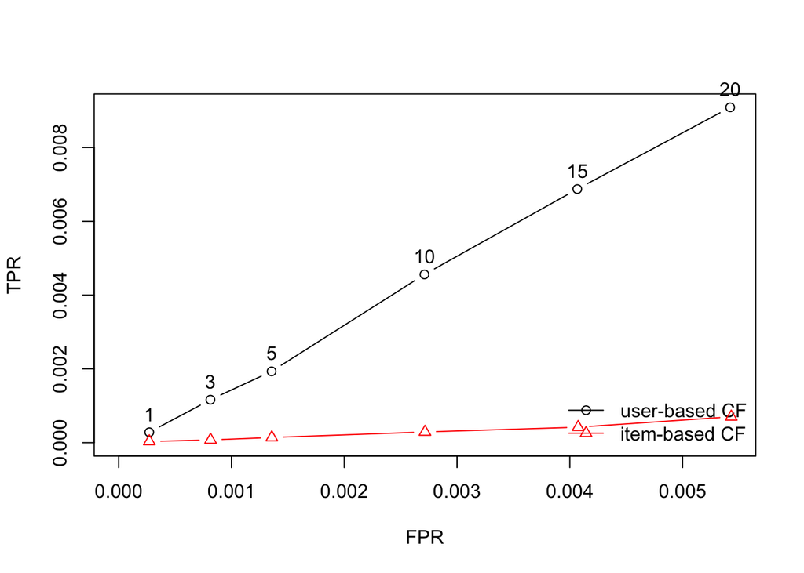

```r
plot(results, annotate=c(1,3), legend="bottomright")
```

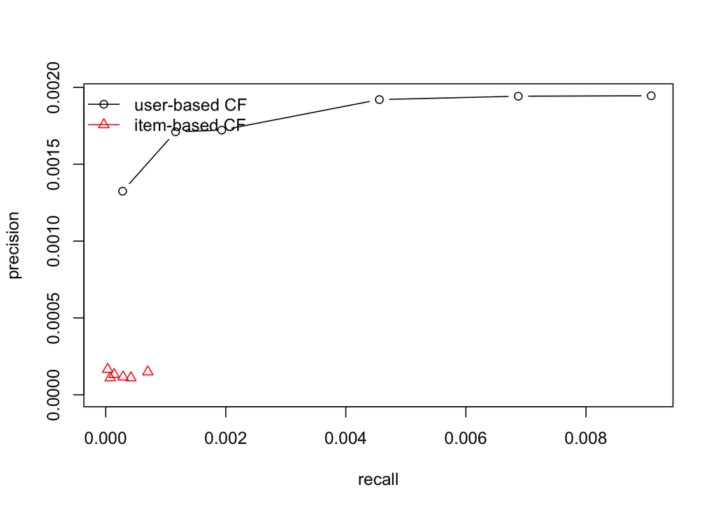

```r
plot(results, "prec/rec", annotate=3, legend="topleft")
```

Ultimately we had much lower error when applying user based collaborative filtering so we chose to use UBCF for our shiny app. This is based on the lower evaluation metrics, namely RMSE. Also oure true positive rate compared to false positive rate was much more desirable for the user based cf. Lastly, we see higher precision even at higher sensitivities for the user based cf which further affirms usage of our user based cf model.